# Predicting Exercise Quality based on Activity Sensors

Author: Sanjay-Srivastava Date: October 16, 2015

# References

Velloso, E.; Bulling, A.; Gellersen, H.; Ugulino, W.; Fuks, H. Qualitative Activity Recognition of Weight Lifting Exercises. Proceedings of 4th International Conference in Cooperation with SIGCHI (Augmented Human ’13) . Stuttgart, Germany: ACM SIGCHI, 2013

For further information on this project, click [here.](http://groupware.les.inf.puc-rio.br/har)

# Synopsis

### The Experiment

Wearable devices like Jawbone Up, Nike FuelBand, and Fitbit collect a large amount of data using activity recognition sensors. Using this data, it is possible to not just report on the ‘quantity’ of exercise, but also it’s quality.

Six participants were asked to perform one set of 10 repetitions of the Unilateral Dumbbell Biceps Curl in five different fashions, identified as classes A, B, C, D and E. Sensors were used to collect data about the quality of the exercise - these sensors were attached to the arm and forearm of participants, as also to the belt and dumbbells they used. Based on readings from these sensors, each exercise session was coded as:

```
(Class A) Exactly according to the specification
(Class B) Throwing the elbows to the front
(Class C) Lifting the dumbbell only halfway
(Class D) Lowering the dumbbell only halfway
(Class E) Throwing the hips to the front
```

### Analysis Goal

Create a Prediction Algorithm that takes a set of sensor readings and predicts the corresponding class. We will test multiple algorithms and select one with sample error rate under 2%.

### Methodology

To develop a prediction model, we will perform the following steps:

1 - Clean the data and run high-level exploratory analysis, leading to:

```
(a) Santization of data
(b) Feature selection
(c) Carve out a chunk of training dataset for cross-validation
(d) Standardization of training, cross-validtaion and testing datasets
```

2 - Test 3 OOB models: Random Forest, Boosted Regression and Linear Discriminant

3 - Apply the results to test dataset comprised of 20 sensor readings and predict the Class outcome

## Load Required Tools

[output not shown]

# Data Cleansing, Exploration & Feature Selection

### Load Data

```r
  download_data = TRUE

  if (file.exists("./Data/pml-training.csv") & file.exists("./Data/pml-testing.csv"))
  {
     training = read.csv("./Data/pml-training.csv")
     testing  = read.csv("./Data/pml-testing.csv")
     download_data = FALSE
  }


  # If the data files are not already downloaded, do it now, and load them in dataframes
  if (download_data)
   {
     setInternet2(use = TRUE)
     url_train = 'https://d396qusza40orc.cloudfront.net/predmachlearn/pml-training.csv'
     url_test  = 'https://d396qusza40orc.cloudfront.net/predmachlearn/pml-testing.csv'
     training = data.frame(fread(url_train))
     testing =  data.frame(fread(url_test))
     write.csv(training, "./Data/pml-training.csv")
     write.csv(testing, "./Data/pml-testing.csv")
   }


   training$classe = factor(training$classe) ## factorize the column: CLASSE
   dim(training)
```

```
## [1] 19622   161
```

```r
   dim(testing)
```

```
## [1]  20 161
```

### Explore Data

We will start with the columns in the raw Test dataset. This is because IF a predictor does not exist in the training dataset, there is no point including it in a prediction model in the first place.

A quick scoping of the reference material shows that the sensor readings are from accelerators attached to the arm, forearm, belt and dumbbell. Visually scanning the the downloaded files, we find that the sensor data is stored in columns that contain ‘arm’, ‘forearm, ’belt’ or ‘dumbbell’.

```r
   sum(complete.cases(testing))
```

```
## [1] 0
```

A seen above, we see that ALL observations have data missing, i.e. is incomplete. Let us now remove the columns that do not have sensor data or are mostly un-populated.

```r
   # check for columns with lots of missing values
   hasValidData = sapply(testing, function(x)
                               ifelse( sum( is.na(x) | x == "" | x == "#DIV/0!" | x == "NA" ) == 0,
                                       TRUE ,
                                       FALSE
                                     )
                        )

   # columns containing sensor data
   hasSensorData = grepl(pattern = "_belt|_arm|_dumbbell|_forearm", names(testing))

   # final list of valuable columns in the testing data
   covars = names(hasValidData)[hasValidData & hasSensorData]
   covars
```

```
##  [1] "roll_belt"            "pitch_belt"           "yaw_belt"
##  [4] "total_accel_belt"     "gyros_belt_x"         "gyros_belt_y"
##  [7] "gyros_belt_z"         "accel_belt_x"         "accel_belt_y"
## [10] "accel_belt_z"         "magnet_belt_x"        "magnet_belt_y"
## [13] "magnet_belt_z"        "roll_arm"             "pitch_arm"
## [16] "yaw_arm"              "total_accel_arm"      "gyros_arm_x"
## [19] "gyros_arm_y"          "gyros_arm_z"          "accel_arm_x"
## [22] "accel_arm_y"          "accel_arm_z"          "magnet_arm_x"
## [25] "magnet_arm_y"         "magnet_arm_z"         "roll_dumbbell"
## [28] "pitch_dumbbell"       "yaw_dumbbell"         "total_accel_dumbbell"
## [31] "gyros_dumbbell_x"     "gyros_dumbbell_y"     "gyros_dumbbell_z"
## [34] "accel_dumbbell_x"     "accel_dumbbell_y"     "accel_dumbbell_z"
## [37] "magnet_dumbbell_x"    "magnet_dumbbell_y"    "magnet_dumbbell_z"
## [40] "roll_forearm"         "pitch_forearm"        "yaw_forearm"
## [43] "total_accel_forearm"  "gyros_forearm_x"      "gyros_forearm_y"
## [46] "gyros_forearm_z"      "accel_forearm_x"      "accel_forearm_y"
## [49] "accel_forearm_z"      "magnet_forearm_x"     "magnet_forearm_y"
## [52] "magnet_forearm_z"
```

```r
   sum(complete.cases(testing[, covars]))
```

```
## [1] 20
```

Note from above that all 20 test obsevations are now complete with data in all 52 predictor columns. If any of these columns do not exist in the training dataset, or are left materially un-populated, we will have to remove those from the list of predictors or apply other cleansing/ imputation techniques.

```r
   train_cols = names(training)[covars]
   length(train_cols)
```

```
## [1] 52
```

```r
   sum(complete.cases(training[, covars]))
```

```
## [1] 19622
```

Fortunately, all 19622 observations have the required 52 predictor columns filled with data. Therefore, there is no need for any further cleansing or imputation.

We will make one more quick check: if the predictor columns in training and test datasets are of the same or comparable data-types.

```r
   unique(sapply(training[, covars], class))
```

```
## [1] "numeric" "integer"
```

```r
   unique(sapply(testing [, covars], class))
```

```
## [1] "numeric" "integer"
```

Since the columns are either integer or numeric, no casting is called for: R automatically converts integers to double as needed in the context.

Next, we will set aside a chunk of training data for cross-validation.

```r
    set.seed(12345)
    training$classe = factor(training$classe) ## factorize the outcome column: CLASSE
    idx = createDataPartition(training$classe, p = 0.6, list = FALSE)
    raw_train = training[ idx, c("classe", covars)]
    raw_valid = training[-idx, c("classe", covars)]
    x = rbind( training   = round(prop.table(table(raw_train$classe)),3),
               validating = round(prop.table(table(raw_valid$classe)),3)
              )
    x
```

```
##                A     B     C     D     E
## training   0.284 0.194 0.174 0.164 0.184
## validating 0.284 0.193 0.174 0.164 0.184
```

Note that in the proportions of each class in the two partitions are similar, meaning that overall, the partitions are representative of the whole training dataset as far as outcomes are concerned.

Finally, we will standardize the training data, and apply those statistics to standardize cross-validation and test datasets.

```r
    ## Center and Scale the Training dataset; remove the column: CLASSE
    standardization_stats = preProcess(raw_train[, covars])
    standardization_stats
```

```
##
## Call:
## preProcess.default(x = raw_train[, covars])
##
## Created from 11776 samples and 52 variables
## Pre-processing: centered, scaled
```

```r
    x = predict(standardization_stats, raw_train[, covars])
    std_train = data.frame(classe = raw_train$classe, x[, covars])

    ## Standardize the Validation dataset using pre-processing stats from the Training dataset
    y = predict(standardization_stats, raw_valid[, covars])
    std_valid = data.frame(classe = raw_valid$classe, y[, covars])

    ## Standardize the Test dataset using pre-processing stats from Training dataset
    std_test = data.frame(predict(standardization_stats, testing[, covars]))

    dim(std_train)
```

```
## [1] 11776    53
```

```r
    dim(std_valid)
```

```
## [1] 7846   53
```

```r
    dim(std_test)
```

```
## [1] 20 52
```

The test dataset does not have the column: classe - that’s the value we will predict using a model below.

# Building Prediction Model

```r
    modelObj_rpart = rpart(classe ~ ., data = std_train, method ="class")
    prp(modelObj_rpart)
```

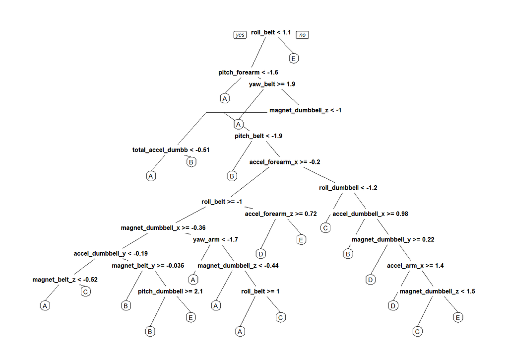

The Principle Component Analysis points to about 25 PCs:

```r
    modelObj_pca = preProcess(std_train [, covars], method = "pca")
    modelObj_pca
```

```
##
## Call:
## preProcess.default(x = std_train[, covars], method = "pca")
##
## Created from 11776 samples and 52 variables
## Pre-processing: principal component signal extraction, scaled, centered
##
## PCA needed 25 components to capture 95 percent of the variance
```

### Random Forest

```r
    model_file = "./Objects/modelObj_rf.RData"
    if (!file.exists(model_file))
    {
      tr_Control <- trainControl(method = "repeatedcv", number = 5, repeats = 1)
      modelObj_rf = randomForest( classe ~ .,
                               data = std_train,
                               trControl = tr_Control)
      save(modelObj_rf, file = model_file)
    }

    ## run model
    if(file.exists(model_file))
    {
      if (!exists("modelObj_rf")) {load(file = model_file, verbose = TRUE)}

      predObj_train_rf = predict(modelObj_rf, std_train[, covars])
      predObj_valid_rf = predict(modelObj_rf, std_valid[, covars])
      predObj_test_rf  = predict(modelObj_rf, std_test [, covars])

      modelObj_rf

    }
```

```
## Loading objects:
##   modelObj_rf
```

```
##
## Call:
##  randomForest(formula = classe ~ ., data = std_train, trControl = tr_Control)
##                Type of random forest: classification
##                      Number of trees: 500
## No. of variables tried at each split: 7
##
##         OOB estimate of  error rate: 0.7%
## Confusion matrix:
##      A    B    C    D    E  class.error
## A 3345    3    0    0    0 0.0008960573
## B   16 2257    6    0    0 0.0096533567
## C    0    9 2038    7    0 0.0077896787
## D    0    0   24 1903    3 0.0139896373
## E    0    1    4    9 2151 0.0064665127
```

```r
    if(exists("predObj_train_rf") & exists("std_train"))
    {
      cmObj_train_rf = confusionMatrix(predObj_train_rf, std_train$classe)
      cmObj_train_rf$overall["Accuracy"]
    }
```

```
## Accuracy
##        1
```

```r
    if(exists("predObj_train_rf") & exists("std_valid"))
    {
      cmObj_valid_rf = confusionMatrix(predObj_valid_rf, std_valid$classe)
      cmObj_valid_rf$overall["Accuracy"]
    }
```

```
##  Accuracy
## 0.9940097
```

As seen from the above, when applied to the cross-validation dataset, the accuracy is over 99%. Normally, no further algorithms are required to be tested, but in this case, we will go ahead and create two other models - boosted regression and linear discriminant to test out how close/ far they are relative to random forest.

### Generalized Booseted Regression

```r
    model_file = "./Objects/modelObj_gbm.RData"
    if (!file.exists(model_file))
    {
      tr_Control <- trainControl(method = "repeatedcv", number = 5, repeats = 1)
      modelObj_gbm = suppressMessages(train( classe ~ .,
                                          data = std_train,
                                          method = "gbm",
                                          trControl = tr_Control,
                                          verbose = FALSE))
      save(modelObj_gbm, file = model_file)
    }

    ## Run model
    if(file.exists(model_file))
    {
      if (!exists("modelObj_gbm")) {load(file = model_file, verbose = TRUE)}

      predObj_train_gbm = predict(modelObj_gbm, std_train[, covars])
      predObj_valid_gbm = predict(modelObj_gbm, std_valid[, covars])
      predObj_test_gbm  = predict(modelObj_gbm, std_test [, covars])

      modelObj_gbm

    }
```

```
## Loading objects:
##   modelObj_gbm
```

```
## Stochastic Gradient Boosting
##
## 11776 samples
##    52 predictor
##     5 classes: 'A', 'B', 'C', 'D', 'E'
##
## No pre-processing
## Resampling: Cross-Validated (5 fold, repeated 1 times)
## Summary of sample sizes: 9420, 9421, 9421, 9421, 9421
## Resampling results across tuning parameters:
##
##   interaction.depth  n.trees  Accuracy   Kappa      Accuracy SD
##   1                   50      0.7523775  0.6862582  0.007435147
##   1                  100      0.8226061  0.7754488  0.008914486
##   1                  150      0.8542802  0.8155976  0.009028195
##   2                   50      0.8519874  0.8123997  0.009178710
##   2                  100      0.9059948  0.8810207  0.005083313
##   2                  150      0.9299422  0.9113365  0.003004682
##   3                   50      0.8956350  0.8678511  0.004804075
##   3                  100      0.9387735  0.9225309  0.007110940
##   3                  150      0.9573709  0.9460703  0.005179553
##   Kappa SD
##   0.009307743
##   0.011244351
##   0.011329124
##   0.011654344
##   0.006394354
##   0.003783493
##   0.006053909
##   0.008965983
##   0.006543198
##
## Tuning parameter 'shrinkage' was held constant at a value of 0.1
##
## Tuning parameter 'n.minobsinnode' was held constant at a value of 10
## Accuracy was used to select the optimal model using  the largest value.
## The final values used for the model were n.trees = 150,
##  interaction.depth = 3, shrinkage = 0.1 and n.minobsinnode = 10.
```

```r
    if(exists("predObj_train_gbm") & exists("std_train"))
    {
      cmObj_train_gbm = confusionMatrix(predObj_train_gbm, std_train$classe)
      cmObj_train_gbm$overall["Accuracy"]
    }
```

```
## Accuracy
## 0.974949
```

```r
    if(exists("predObj_train_gbm") & exists("std_valid"))
    {
      cmObj_valid_gbm = confusionMatrix(predObj_valid_gbm, std_valid$classe)
      cmObj_valid_gbm$overall["Accuracy"]
    }
```

```
##  Accuracy
## 0.9613816
```

As seen from above, the accuracy of the model is still pretty good at 96% + when applied to the cross-validation dataset.

### Linear Discriminant Analysis

```r
    model_file = "./Objects/modelObj_lda.RData"
    if (!file.exists(model_file))
    {
      tr_Control <- trainControl(method = "repeatedcv", number = 5, repeats = 1)
      modelObj_lda = suppressMessages(train( classe ~ .,
                                          data = std_train,
                                          method = "lda",
                                          trControl = tr_Control,
                                          verbose = FALSE))
      save(modelObj_lda, file = model_file)
    }

    ## run model
    if(file.exists(model_file))
    {
      if (!exists("modelObj_lda")) {load(file = model_file, verbose = TRUE)}

      predObj_train_lda = predict(modelObj_lda, std_train[, covars])
      predObj_valid_lda = predict(modelObj_lda, std_valid[, covars])
      predObj_test_lda  = predict(modelObj_lda, std_test [, covars])

      modelObj_lda

    }
```

```
## Loading objects:
##   modelObj_lda
```

```
## Linear Discriminant Analysis
##
## 11776 samples
##    52 predictor
##     5 classes: 'A', 'B', 'C', 'D', 'E'
##
## No pre-processing
## Resampling: Cross-Validated (5 fold, repeated 1 times)
## Summary of sample sizes: 9420, 9421, 9421, 9421, 9421
## Resampling results
##
##   Accuracy   Kappa      Accuracy SD  Kappa SD
##   0.6989643  0.6188443  0.01059865   0.01334785
##
##
```

```r
    if(exists("predObj_train_lda") & exists("std_train"))
    {
      cmObj_train_lda = confusionMatrix(predObj_train_lda, std_train$classe)
      cmObj_train_lda$overall["Accuracy"]
    }
```

```
##  Accuracy
## 0.7063519
```

```r
    if(exists("predObj_train_lda") & exists("std_valid"))
    {
      cmObj_valid_lda = confusionMatrix(predObj_valid_lda, std_valid$classe)
      cmObj_valid_lda$overall["Accuracy"]
    }
```

```
##  Accuracy
## 0.7039256
```

# Summary

```r
    save_file = "./Data/Predictions.csv"
    all_results = data.frame(testing[, covars],
                             Prediction_rf  = predObj_test_rf,
                             Prediction_gbm = predObj_test_gbm,
                             Prediction_lda = predObj_test_lda)
    write.csv(all_results, save_file)
    df = read.csv(save_file, header = T)
    df[, c("Prediction_rf", "Prediction_gbm", "Prediction_lda")]
```

```
##    Prediction_rf Prediction_gbm Prediction_lda
## 1              B              B              B
## 2              A              A              A
## 3              B              B              B
## 4              A              A              C
## 5              A              A              C
## 6              E              E              E
## 7              D              D              D
## 8              B              B              D
## 9              A              A              A
## 10             A              A              A
## 11             B              B              D
## 12             C              C              A
## 13             B              B              B
## 14             A              A              A
## 15             E              E              E
## 16             E              E              A
## 17             A              A              A
## 18             B              B              B
## 19             B              B              B
## 20             B              B              B
```

```r
    options( warn = 0)
```

### Post-Script

This section is not part of the Analysis/ Report. Readers may ignore this section.

#### Coursera Submission

This code is to generate text files for submission to Coursera only, and is not part of the analysis.

```r
  pml_write_files = function(x){
    n = length(x)
    for(i in 1:n){
      filename = paste0("./Submission/problem_id_",i,".txt")
      write.table( x[i],
                   file = filename,
                   quote = FALSE,
                   row.names = FALSE,
                   col.names=FALSE)
    }
  }

  pml_write_files(all_results$Prediction_rf)
```

```r
    # Standardized datasets
    write.csv(std_train, "./Data/std_train.csv")
    write.csv(std_valid, "./Data/std_valid.csv")
    write.csv(std_test , "./Data/std_test.csv" )


    # Model objects
    save(modelObj_rpart,    file = "./Objects/modelObj_rpart.RData"   )
    save(modelObj_pca,      file = "./Objects/modelObj_pca.RData"     )
    save(modelObj_rf,       file = "./Objects/modelObj_rf.RData"      )
    save(modelObj_gbm,      file = "./Objects/modelObj_gbm.RData"     )
    save(modelObj_lda,      file = "./Objects/modelObj_lda.RData"     )

    # Prediction objects
    save(predObj_train_rf,  file = "./Objects/predObj_train_rf.RData" )
    save(predObj_valid_rf,  file = "./Objects/predObj_valid_rf.RData" )
    save(predObj_test_rf,   file = "./Objects/predObj_test_rf.RData"  )
    save(predObj_train_gbm, file = "./Objects/predObj_train_gbm.RData")
    save(predObj_valid_gbm, file = "./Objects/predObj_valid_gbm.RData")
    save(predObj_test_gbm,  file = "./Objects/predObj_test_gbm.RData" )
    save(predObj_train_lda, file = "./Objects/predObj_train_lda.RData")
    save(predObj_valid_lda, file = "./Objects/predObj_valid_lda.RData")
    save(predObj_test_lda,  file = "./Objects/predObj_test_lda.RData" )

    # Confusion-Matrix objects
    save(cmObj_train_rf,    file = "./Objects/cmObj_train_rf.RData"   )
    save(cmObj_valid_rf,    file = "./Objects/cmObj_valid_rf.RData"   )
    save(cmObj_train_gbm,   file = "./Objects/cmObj_train_gbm.RData"  )
    save(cmObj_valid_gbm,   file = "./Objects/cmObj_valid_gbm.RData"  )
    save(cmObj_train_lda,   file = "./Objects/cmObj_train_lda.RData"  )
    save(cmObj_valid_lda,   file = "./Objects/cmObj_valid_lda.RData"  )
```